# Bitacora_3 Borrador

Gustavo Amador Fonseca C20451, Henri Gerard Gabert Hidalgo B93096

2026-11-25

# Preparación de datos

## Parámetros

```r
library(readxl)

fecha_valoracion <- as.Date("2026-11-24")
fecha_inicio    <- as.Date("2021-11-24")
vencimiento     <- as.Date("2027-01-15")

S0 <- 66.33
K  <- 67.50

dias <- as.numeric(vencimiento - fecha_valoracion)
T    <- dias / 365
```

## Curva par del Tesoro

Las tasas se conservan en porcentaje y en decimal.

```r
tesoro <- read.csv(
  "daily-treasury-rates.csv",
  check.names = FALSE,
  na.strings = c("", "N/A", "NA", ".")
)

tesoro$Date <- as.Date(tesoro$Date, format = "%m/%d/%Y")

# Seleccionar la fecha de valoración.
fila <- tesoro[tesoro$Date == fecha_valoracion, ]

# Columnas correspondientes a plazos.
columnas <- grep(
  "^[0-9.]+\\s+(Mo|Month|Yr|Year)$",
  names(tesoro),
  ignore.case = TRUE
)

plazos <- names(tesoro)[columnas]

# Convertir las etiquetas de plazo a años.
plazo_anios <- as.numeric(sub("\\s+.*", "", plazos))

plazo_anios <- plazo_anios / ifelse(
  grepl("mo", plazos, ignore.case = TRUE),
  12,
  1
)

curva_par <- data.frame(
  plazo = plazos,
  plazo_anios = plazo_anios,
  tasa_pct = as.numeric(unlist(fila[columnas]))
)

curva_par$tasa <- curva_par$tasa_pct / 100

curva_par <- curva_par[order(curva_par$plazo_anios), ]
rownames(curva_par) <- NULL

curva_par
```

```
##        plazo plazo_anios tasa_pct   tasa
## 1       1 Mo  0.08333333     4.21 0.0421
## 2  1.5 Month  0.12500000     4.27 0.0427
## 3       2 Mo  0.16666667     4.28 0.0428
## 4       3 Mo  0.25000000     4.36 0.0436
## 5       4 Mo  0.33333333     4.36 0.0436
## 6       6 Mo  0.50000000     4.46 0.0446
## 7       1 Yr  1.00000000     4.59 0.0459
## 8       2 Yr  2.00000000     4.63 0.0463
## 9       3 Yr  3.00000000     4.67 0.0467
## 10      5 Yr  5.00000000     4.69 0.0469
## 11      7 Yr  7.00000000     4.79 0.0479
## 12     10 Yr 10.00000000     4.91 0.0491
## 13     20 Yr 20.00000000     5.33 0.0533
## 14     30 Yr 30.00000000     5.30 0.0530
```

## Histórico diario de la tasa a tres meses

`dtb3` conserva los datos faltantes; `dtb3_validos` contiene las observaciones disponibles.

```r
datos_dtb3 <- read_excel(
  "DTB3.xlsx",
  sheet = "Daily",
  na = c("", ".", "NA", "N/A")
)

dtb3 <- data.frame(
  fecha = as.Date(datos_dtb3$observation_date),
  tasa_pct = as.numeric(datos_dtb3$DTB3)
)

dtb3$tasa <- dtb3$tasa_pct / 100

dtb3 <- subset(
  dtb3,
  fecha >= fecha_inicio & fecha <= fecha_valoracion
)

dtb3 <- dtb3[order(dtb3$fecha), ]
rownames(dtb3) <- NULL

dtb3_validos <- subset(dtb3, !is.na(tasa))

head(dtb3)
```

```
##        fecha tasa_pct  tasa
## 1 2021-11-24     0.06 6e-04
## 2 2021-11-25       NA    NA
## 3 2021-11-26     0.06 6e-04
## 4 2021-11-29     0.06 6e-04
## 5 2021-11-30     0.05 5e-04
## 6 2021-12-01     0.06 6e-04
```

```r
tail(dtb3)
```

```
##           fecha tasa_pct   tasa
## 1299 2026-11-16     4.16 0.0416
## 1300 2026-11-17     4.15 0.0415
## 1301 2026-11-18     4.16 0.0416
## 1302 2026-11-19     4.16 0.0416
## 1303 2026-11-20     4.13 0.0413
## 1304 2026-11-23     4.18 0.0418
```

## Opciones de Nutrien: 15 de enero de 2027

Cotizaciones transcritas de la captura del 24 de noviembre de 2026. Los precios están expresados en USD por acción.

### Calls

```r
calls <- read.table(
  header = TRUE,
  text = "
strike bid ask last volumen interes_abierto IV_pct delta
55.0 10.90 12.90 10.20 0 178 40.7416 0.9213
57.5 9.10 10.40 7.99 0 234 40.6569 0.8629
60.0 6.70 8.10 6.45 0 955 34.5330 0.8184
62.5 5.20 6.00 4.40 0 86 34.6820 0.7145
65.0 3.60 4.00 3.70 2 303 33.7911 0.5983
67.5 2.40 3.00 2.90 1 256 32.9173 0.4723
70.0 1.40 2.00 1.73 10 2102 31.9903 0.3476
72.5 0.95 1.40 1.15 18 2471 33.3601 0.2548
75.0 0.35 0.80 0.60 5 2185 31.0923 0.1531
77.5 0.25 0.55 0.20 0 380 32.6433 0.1083
80.0 0.10 0.50 0.22 32 3472 34.7572 0.0807
"
)

calls$tipo <- "call"
```

### Puts

```r
puts <- read.table(
  header = TRUE,
  text = "
strike bid ask last volumen interes_abierto IV_pct delta
55.0 0.05 0.60 0.65 0 950 36.2395 -0.0762
57.5 0.40 0.70 0.55 0 114 34.2851 -0.1237
60.0 0.80 1.15 0.95 1 4678 33.3020 -0.1999
62.5 1.40 1.85 1.47 14 348 32.3901 -0.3004
65.0 2.00 2.95 3.50 0 1402 30.7392 -0.4201
67.5 3.50 4.40 4.65 0 88 32.3697 -0.5468
70.0 4.60 5.70 5.48 1 283 27.6764 -0.6969
72.5 6.50 7.60 8.75 0 158 26.8212 -0.8132
75.0 8.60 10.30 10.95 0 1661 31.3340 -0.8528
77.5 10.80 12.20 13.35 0 124 25.0769 -0.9559
80.0 13.00 15.20 16.50 0 393 29.3793 -0.9583
"
)

puts$tipo <- "put"
```

### Preparación de la cadena

```r
opciones_enero <- rbind(calls, puts)

opciones_enero$fecha       <- fecha_valoracion
opciones_enero$vencimiento <- vencimiento
opciones_enero$S0          <- S0
opciones_enero$T           <- T
opciones_enero$estilo      <- "americana"

opciones_enero$mid <- (
  opciones_enero$bid + opciones_enero$ask
) / 2

opciones_enero$sigma_implicita <- opciones_enero$IV_pct / 100
opciones_enero
```

```
##    strike   bid   ask  last volumen interes_abierto  IV_pct   delta tipo
## 1    55.0 10.90 12.90 10.20       0             178 40.7416  0.9213 call
## 2    57.5  9.10 10.40  7.99       0             234 40.6569  0.8629 call
## 3    60.0  6.70  8.10  6.45       0             955 34.5330  0.8184 call
## 4    62.5  5.20  6.00  4.40       0              86 34.6820  0.7145 call
## 5    65.0  3.60  4.00  3.70       2             303 33.7911  0.5983 call
## 6    67.5  2.40  3.00  2.90       1             256 32.9173  0.4723 call
## 7    70.0  1.40  2.00  1.73      10            2102 31.9903  0.3476 call
## 8    72.5  0.95  1.40  1.15      18            2471 33.3601  0.2548 call
## 9    75.0  0.35  0.80  0.60       5            2185 31.0923  0.1531 call
## 10   77.5  0.25  0.55  0.20       0             380 32.6433  0.1083 call
## 11   80.0  0.10  0.50  0.22      32            3472 34.7572  0.0807 call
## 12   55.0  0.05  0.60  0.65       0             950 36.2395 -0.0762  put
## 13   57.5  0.40  0.70  0.55       0             114 34.2851 -0.1237  put
## 14   60.0  0.80  1.15  0.95       1            4678 33.3020 -0.1999  put
```

[output cut: 31 more lines]

### Call y put seleccionadas

```r
call_enero <- subset(
  opciones_enero,
  tipo == "call" & strike == K
)

put_enero <- subset(
  opciones_enero,
  tipo == "put" & strike == K
)

# Valores individuales para usar directamente en cálculos.
C_mercado <- call_enero$mid
P_mercado <- put_enero$mid

sigma_call <- call_enero$sigma_implicita
sigma_put  <- put_enero$sigma_implicita

data.frame(
  S0 = S0,
  K = K,
  dias = dias,
  T = T,
  C_mercado = C_mercado,
  P_mercado = P_mercado,
  sigma_call = sigma_call,
  sigma_put = sigma_put
)
```

```
##      S0    K dias         T C_mercado P_mercado sigma_call sigma_put
## 1 66.33 67.5   52 0.1424658       2.7      3.95   0.329173  0.323697
```

## Construcción de la curva cupón cero

Se aplica bootstrap con cupones semestrales y nominal unitario. Las tasas par faltantes se interpolan linealmente.

Para plazos menores de seis meses se utiliza descuento simple. Después del bootstrap se interpola linealmente el logaritmo de los factores de descuento.

### Tasas par en la malla semestral

```r
# Vencimientos: 0.5, 1, 1.5, ..., 30 años.
tiempos_sem <- seq(
  from = 0.5,
  to = max(curva_par$plazo_anios),
  by = 0.5
)

# Completar las tasas par mediante interpolación lineal.
tasas_sem <- approx(
  x = curva_par$plazo_anios,
  y = curva_par$tasa,
  xout = tiempos_sem,
  method = "linear"
)$y
```

### Bootstrap de factores de descuento

```r
descuentos_sem <- numeric(length(tiempos_sem))

for (n in seq_along(tiempos_sem)) {

  cupon <- tasas_sem[n] / 2

  # Para n = 1, esta suma es cero.
  suma_descuentos <- sum(
    descuentos_sem[seq_len(n - 1)]
  )

  descuentos_sem[n] <- (
    1 - cupon * suma_descuentos
  ) / (1 + cupon)
}

curva_sem <- data.frame(
  plazo_anios = tiempos_sem,
  tasa_par = tasas_sem,
  descuento = descuentos_sem
)
descuentos_sem
```

```
##  [1] 0.9781864 0.9556192 0.9338994 0.9124885 0.8913858 0.8705903 0.8505697
##  [8] 0.8309653 0.8117690 0.7929729 0.7736310 0.7545480 0.7357248 0.7171622
## [15] 0.6991663 0.6814582 0.6640363 0.6468989 0.6300442 0.6134704 0.5970958
## [22] 0.5809945 0.5651648 0.5496050 0.5343131 0.5192874 0.5045259 0.4900266
## [29] 0.4757874 0.4618062 0.4480809 0.4346091 0.4213887 0.4084174 0.3956926
## [36] 0.3832122 0.3709736 0.3589743 0.3472119 0.3356838 0.3271545 0.3188513
## [43] 0.3107681 0.3028991 0.2952385 0.2877807 0.2805203 0.2734521 0.2665709
## [50] 0.2598718 0.2533498 0.2470002 0.2408185 0.2348002 0.2289409 0.2232363
## [57] 0.2176824 0.2122752 0.2070107 0.2018851
```

### Incorporación de los plazos menores de seis meses

```r
cortos <- subset(curva_par, plazo_anios < 0.5)

curva_corta <- data.frame(
  plazo_anios = cortos$plazo_anios,
  tasa_par = cortos$tasa,
  descuento = 1 / (1 + cortos$tasa * cortos$plazo_anios)
)

curva_cero <- rbind(curva_corta, curva_sem)

curva_cero <- curva_cero[
  order(curva_cero$plazo_anios),
]

rownames(curva_cero) <- NULL

# Tasas cero con capitalización continua.
curva_cero$tasa_cero <- (
  -log(curva_cero$descuento) / curva_cero$plazo_anios
)

curva_cero$tasa_cero_pct <- 100 * curva_cero$tasa_cero

head(curva_cero, 10)
```

```
##    plazo_anios tasa_par descuento  tasa_cero tasa_cero_pct
## 1   0.08333333   0.0421 0.9965039 0.04202632      4.202632
## 2   0.12500000   0.0427 0.9946908 0.04258645      4.258645
## 3   0.16666667   0.0428 0.9929172 0.04264807      4.264807
## 4   0.25000000   0.0436 0.9892175 0.04336409      4.336409
## 5   0.33333333   0.0436 0.9856749 0.04328621      4.328621
## 6   0.50000000   0.0446 0.9781864 0.04410998      4.410998
## 7   1.00000000   0.0459 0.9556192 0.04539581      4.539581
## 8   1.50000000   0.0461 0.9338994 0.04559104      4.559104
## 9   2.00000000   0.0463 0.9124885 0.04578989      4.578989
## 10  2.50000000   0.0465 0.8913858 0.04599119      4.599119
```

### Funciones para consultar cualquier plazo

```r
# Incluir el origen: p(0,0) = 1 y log(p(0,0)) = 0.
log_p0 <- approxfun(
  x = c(0, curva_cero$plazo_anios),
  y = c(0, log(curva_cero$descuento)),
  method = "linear",
  rule = 1
)

# Factor de descuento p(0,t).
p0 <- function(t) {
  exp(log_p0(t))
}

# Tasa cero continua y(0,t), en decimal.
y0 <- function(t) {
  ifelse(t > 0, -log_p0(t) / t, NA_real_)
}
```

### Descuento al vencimiento de las opciones

```r
# T ya fue definido como días al vencimiento / 365.
P_T <- p0(T)
r_T <- y0(T)

data.frame(
  vencimiento = vencimiento,
  plazo_anios = T,
  descuento = P_T,
  tasa_cero = r_T,
  tasa_cero_pct = 100 * r_T
)
```

```
##   vencimiento plazo_anios descuento  tasa_cero tasa_cero_pct
## 1  2027-01-15   0.1424658  0.993947 0.04261667      4.261667
```

### Tasas forward por intervalo

```r
tiempos <- c(0, curva_cero$plazo_anios)
log_descuentos <- c(0, log(curva_cero$descuento))

curva_forward <- data.frame(
  desde = head(tiempos, -1),
  hasta = tail(tiempos, -1),
  forward_continua = -diff(log_descuentos) / diff(tiempos)
)

curva_forward$forward_pct <- (
  100 * curva_forward$forward_continua
)

head(curva_forward, 10)
```

```
##         desde      hasta forward_continua forward_pct
## 1  0.00000000 0.08333333       0.04202632    4.202632
## 2  0.08333333 0.12500000       0.04370670    4.370670
## 3  0.12500000 0.16666667       0.04283293    4.283293
## 4  0.16666667 0.25000000       0.04479614    4.479614
## 5  0.25000000 0.33333333       0.04305256    4.305256
## 6  0.33333333 0.50000000       0.04575752    4.575752
## 7  0.50000000 1.00000000       0.04668164    4.668164
## 8  1.00000000 1.50000000       0.04598149    4.598149
## 9  1.50000000 2.00000000       0.04638644    4.638644
## 10 2.00000000 2.50000000       0.04679639    4.679639
```

# Tareas (a) y (b)

## Configuración y herramientas

```r
# Foto de todo lo que existe antes de (a) y (b): al final se verifica que nada cambio
.previos_b3 <- ls(globalenv())
.copia_b3   <- mget(.previos_b3, envir = globalenv())

TMAX_A          <- 10          # la tarea (a) llega a 10 anios
CONVERSION_DTB3 <- "continua"  # DTB3 viene en base descuento: "continua" o "ninguna"
DIAS_LETRA      <- 91          # plazo de la letra de DTB3, en dias
D_REG           <- 1 / 252     # paso de la regresion: un dia habil
N_BOOT          <- 500         # historias para las barras de error de (b)
N_MC            <- 20000       # trayectorias del chequeo Monte Carlo de la Prop. 21.4
SEMILLA         <- 20261126
DIR_FIG <- "figuras"; DIR_SAL <- "salidas"
for (carpeta_b3 in c(DIR_FIG, DIR_SAL)) dir.create(carpeta_b3, showWarnings = FALSE)
options(width = 120)
set.seed(SEMILLA)

pct <- function(x, d = 2) sprintf(paste0("%.", d, "f %%"), 100 * x)
pb  <- function(x, d = 1) sprintf(paste0("%.", d, "f pb"), 1e4 * x)

# --- Capa de verificacion: cada chequeo queda registrado ---
CHEQUEOS <- data.frame()
chequeo <- function(nombre, valor, referencia, pasa, podia_fallar = TRUE, nota = "") {
  res <- if (is.na(pasa)) "INFO" else if (pasa) "PASA" else "FALLA"
  CHEQUEOS <<- rbind(CHEQUEOS, data.frame(chequeo = nombre, valor = valor, referencia = referencia,
                                          resultado = res,
                                          podia_fallar = if (podia_fallar) "si" else "no (circular)",
                                          nota = nota, stringsAsFactors = FALSE))
  cat(sprintf("  [%-5s] %s: %s   (ref.: %s)%s\n", res, nombre, valor, referencia,
              if (nchar(nota)) paste0("\n          ", nota) else ""))
}

# --- Cap. 19 ---
tasa_swap   <- function(p_T0, p_Ti, delta) (p_T0 - p_Ti[length(p_Ti)]) / (delta * sum(p_Ti))  # Prop. 19.8
precio_bono <- function(cpn, p_Ti, delta) cpn * delta * sum(p_Ti) + p_Ti[length(p_Ti)]       # (19.17)
p_base <- function(t) exp(-(0.05 * t - 0.02 * (1 - exp(-t))))
# caso base 9/11: f = 0.05 - 0.02 e^{-T}


curva_variante <- function(cp, interp = c("lineal", "spline"), corto = c("simple", "semestral")) {
  interp <- match.arg(interp); corto <- match.arg(corto)
  cp <- cp[!is.na(cp$tasa), ]; cp <- cp[order(cp$plazo_anios), ]
  Tg <- seq(0.5, max(cp$plazo_anios), by = 0.5)
  largo <- cp$plazo_anios >= 0.5
  cg <- if (interp == "lineal") approx(cp$plazo_anios, cp$tasa, xout = Tg)$y else
    splinefun(cp$plazo_anios[largo], cp$tasa[largo], method = "monoH.FC")(Tg)
  p <- numeric(length(Tg))
  for (j in seq_along(Tg)) p[j] <- (1 - cg[j] / 2 * sum(p[seq_len(j - 1)])) / (1 + cg[j] / 2)
  ct <- cp[!largo, ]
  pc <- if (corto == "simple") 1 / (1 + ct$tasa * ct$plazo_anios) else (1 + ct$tasa / 2)^(-2 * ct$plazo_anios)
  TT <- c(ct$plazo_anios, Tg); pp <- c(pc, p)
  list(T = TT, p = pp, y = -log(pp) / TT, f = -diff(log(c(1, pp))) / diff(c(0, TT)), par = c(ct$tasa, cg),
       en_malla = c(rep(FALSE, nrow(ct)), rep(TRUE, length(Tg))))
}
p_var <- function(cv, t) exp(approx(c(0, cv$T), c(0, log(cv$p)), xout = t)$y)

# --- Caps. 20-21: Vasicek, Prop. 21.4 ---
B_vas <- function(tau, a) (1 - exp(-a * tau)) / a
A_vas <- function(tau, a, b, s) { B <- B_vas(tau, a); (B - tau) * (a * b - s^2 / 2) / a^2 - s^2 * B^2 / (4 * a) }
p_vas <- function(t, r, a, b, s) exp(A_vas(t, a, b, s) - B_vas(t, a) * r)
y_vas <- function(t, r, a, b, s) -log(p_vas(t, r, a, b, s)) / t

# Regresion AR(1) exacta (lab 19/11): beta = e^{-aD}, alpha = (b/a)(1 - beta), sd(e) = sigma sqrt((1-beta^2)/(2a))
est_vasicek <- function(x_r, D = D_REG) {
  x <- x_r[-length(x_r)]; y <- x_r[-1]
  fit <- lm(y ~ x); cf <- unname(coef(fit)); V <- unname(vcov(fit))
  al <- cf[1]; be <- cf[2]; se <- summary(fit)$sigma
  if (!(be > 0 && be < 1)) return(list(ok = FALSE, beta = be, alpha = al))
  a <- -log(be) / D; mu <- al / (1 - be); s <- se * sqrt(2 * a / (1 - be^2))
  ee_a <- sqrt(V[2, 2]) / (be * D)
  g <- c(1 / (1 - be), al / (1 - be)^2); ee_mu <- sqrt(drop(t(g) %*% V %*% g))
  list(ok = TRUE, a = a, b = a * mu, mu = mu, s = s, alpha = al, beta = be, sd_e = se,
       ee_a = ee_a, ee_mu = ee_mu, n = length(x), fit = fit)
}
sim_hist <- function(nrep, n_obs, r1, a, b, s, D = D_REG) {
  be <- exp(-a * D); mu <- b / a; sd1 <- s * sqrt((1 - be^2) / (2 * a))
  R <- matrix(0, n_obs, nrep); R[1, ] <- r1
  for (j in 2:n_obs) R[j, ] <- mu + be * (R[j - 1, ] - mu) + sd1 * rnorm(nrep)
  R
}
est_columnas <- function(R, D = D_REG) {
  X <- R[-nrow(R), , drop = FALSE]; Y <- R[-1, , drop = FALSE]; nf <- nrow(X)
  mx <- colMeans(X); my <- colMeans(Y)
  Xc <- X - rep(mx, each = nf); Yc <- Y - rep(my, each = nf)
  be <- colSums(Xc * Yc) / colSums(Xc^2); al <- my - be * mx
  e <- Y - rep(al, each = nf) - X * rep(be, each = nf)
  se <- sqrt(colSums(e^2) / (nf - 2))
  a <- ifelse(be > 0 & be < 1, -log(be) / D, NA)
  mu <- al / (1 - be); s <- se * sqrt(2 * a / (1 - be^2))
  cbind(a = a, mu = mu, b = a * mu, s = s)
}
# Ajustar SOLO b: y(0,t) es lineal en b,  y = y(b = 0) + b (t - B)/(a t)  => solucion cerrada
calibrar_b <- function(Tc, ym, r0, a, s) {
  c1 <- (Tc - B_vas(Tc, a)) / (a * Tc); y00 <- y_vas(Tc, r0, a, 0, s)
  sum(c1 * (ym - y00)) / sum(c1^2)
}
cuantil <- function(v, pr = c(.05, .5, .95)) quantile(v, pr, na.rm = TRUE, names = FALSE)
```

## ¿De dónde salen $A$ y $B$ en Vasicek?

La parametrización del código es $dr_s=(b-ar_s)\,ds+\sigma\,dW_s$. Por eso la media de largo plazo es $b/a$. Para calcular el precio tomamos $b=b^{\mathbb Q}$ y trabajamos bajo la medida neutral al riesgo.

El factor integrante $e^{as}$ permite encontrar la tasa futura. En la regla del producto, $ar_s e^{as}\,ds$ cancela el término $-ar_s e^{as}\,ds$. Al integrar y dividir por $e^{as}$ queda

$$r_s=e^{-a(s-t)}r_t+\frac ba(1-e^{-a(s-t)})
+\sigma\int_t^s e^{-a(s-u)}\,dW_u^{\mathbb Q}.$$

El bono descuenta con la tasa acumulada hasta $T$. Al integrar el primer término, la tasa de hoy queda multiplicada por
$$B(\tau)=\int_t^T e^{-a(s-t)}ds=\frac{1-e^{-a\tau}}a,\qquad \tau=T-t.$$

Un choque que ocurre en $u$ influye en las tasas desde $u$ hasta $T$. Al acumularlo durante ese intervalo recibe el peso $B(T-u)$. Así, la tasa acumulada es
$$\int_t^T r_s\,ds=B(\tau)r_t+\frac ba[\tau-B(\tau)]
+\sigma\int_t^T B(T-u)\,dW_u^{\mathbb Q}.$$

El último término es normal de media cero y varianza $V=\sigma^2\int_0^\tau B(v)^2\,dv$. Como el precio es la esperanza del descuento y $\mathbb E[e^{-Z}]=e^{V/2}$ para $Z\sim N(0,V)$, obtenemos
$$\log p(t,T)=-B(\tau)r_t+\underbrace{\frac ba[B(\tau)-\tau]+\frac
V2}_{A(\tau)}.$$

Al sustituir $B(v)$ en la integral de la varianza e integrar, resulta la expresión utilizada en la función de R:

$$A(\tau)=[B(\tau)-\tau]\left(\frac ba-\frac{\sigma^2}{2a^2}\right)
-\frac{\sigma^2 B(\tau)^2}{4a}.$$

Por tanto, $p(t,T)=\exp[A(\tau)-B(\tau)r_t]$. Al vencimiento $A(0)=B(0)=0$ y el bono paga uno. Para $\tau>0$, $-B(\tau)$ mide el cambio en el logaritmo del precio por unidad de cambio en la tasa corta de hoy.

En la tarea (b), la regresión de DTB3 estima $b^{\mathbb P}$. Usar ese valor en la fórmula de precio da la curva de referencia correspondiente a $\lambda=0$. Luego se calibra $b^{\mathbb Q}$ a la curva observada y se obtiene $\lambda=(b^{\mathbb P}-b^{\mathbb Q})/\sigma$, manteniendo $a$ y $\sigma$ fijos.

## Controles del curso

Estos son los casos de la guía de la Bitácora 3. Si alguno falla, nada de lo que sigue es confiable.

```r
p5b <- p_base(5)
chequeo("p(0,5), curva f = 0.05 - 0.02 e^{-T}", sprintf("%.6f", p5b), "0.794427", abs(p5b - 0.794427) < 5e-7)
```

```
##   [PASA ] p(0,5), curva f = 0.05 - 0.02 e^{-T}: 0.794427   (ref.: 0.794427)
```

```r
Rb <- tasa_swap(1, p_base(1:5), 1)
chequeo("tasa swap anual a 5 anios, caso base (Prop. 19.8)", pct(Rb, 4), "4.6822 %", abs(100 * Rb - 4.6822) < 5e-5)
```

```
##   [PASA ] tasa swap anual a 5 anios, caso base (Prop. 19.8): 4.6822 %   (ref.: 4.6822 %)
```

```r
pv5 <- p_vas(5, 0.03, 0.5, 0.025, 0.01)
chequeo("Vasicek p(0,5), a=0.5 b=0.025 sigma=0.01 r0=3 %", sprintf("%.6f", pv5), "0.808302", abs(pv5 - 0.808302) < 5e-7)
```

```
##   [PASA ] Vasicek p(0,5), a=0.5 b=0.025 sigma=0.01 r0=3 %: 0.808302   (ref.: 0.808302)
```

## Tarea (a): la curva de hoy (cap. 19)

**La curva construida en la sección anterior.** Este chunk no la recalcula: solo la ordena para el análisis. El chequeo verifica que la función `curva_variante()` reproduce `curva_cero` y `curva_forward`. Así, todo lo que se prueba con la función (el caso base y las sensibilidades) también vale para el código de la sección anterior.

```r
cv <- list(T = curva_cero$plazo_anios, p = curva_cero$descuento, y = curva_cero$tasa_cero,
           f = curva_forward$forward_continua, par = curva_cero$tasa_par,
           en_malla = curva_cero$plazo_anios >= 0.5)
nodos <- sort(curva_par$plazo_anios[!is.na(curva_par$tasa)])
k10 <- cv$T <= TMAX_A + 1e-9

rep_cv <- curva_variante(curva_par)
err_rep <- max(abs(rep_cv$p - cv$p), abs(rep_cv$f - cv$f), na.rm = TRUE)
chequeo("curva_variante() reproduce curva_cero y curva_forward",
        sprintf("max dif. = %.1e ; NA en curva_cero: %d", err_rep, sum(is.na(cv$p))), "< 1e-12 y sin NA",
        err_rep < 1e-12 && !anyNA(cv$p) && all(abs(curva_forward$hasta - cv$T) < 1e-12))
```

```
##   [PASA ] curva_variante() reproduce curva_cero y curva_forward: max dif. = 0.0e+00 ; NA en curva_cero: 0   (ref.: < 1e-12 y sin NA)
```

```r
cat(sprintf("\n  Curva del %s ; %d plazos publicados ; p(0,T) al vencimiento de la opcion (%s, T = %.4f): %.6f\n",
            fecha_valoracion, length(nodos), vencimiento, T, p0(T)))
```

```
##
##   Curva del 2026-11-24 ; 14 plazos publicados ; p(0,T) al vencimiento de la opcion (2027-01-15, T = 0.1425): 0.993947
```

```r
tabla_a <- data.frame(T = cv$T, par = 100 * cv$par, p = cv$p, y = 100 * cv$y, f = 100 * cv$f)[k10, ]
print(round(tabla_a[!cv$en_malla[k10] | tabla_a$T %in% c(0.5, 1:10), ], 6), row.names = FALSE)
```

```
##          T  par        p        y        f
##   0.083333 4.21 0.996504 4.202632 4.202632
##   0.125000 4.27 0.994691 4.258645 4.370670
##   0.166667 4.28 0.992917 4.264807 4.283293
##   0.250000 4.36 0.989218 4.336409 4.479614
##   0.333333 4.36 0.985675 4.328621 4.305256
##   0.500000 4.46 0.978186 4.410998 4.575752
##   1.000000 4.59 0.955619 4.539581 4.668164
##   2.000000 4.63 0.912489 4.578989 4.638644
##   3.000000 4.67 0.870590 4.619458 4.721155
##   4.000000 4.68 0.830965 4.629181 4.663666
##   5.000000 4.69 0.792973 4.639324 4.685354
##   6.000000 4.74 0.754548 4.693940 4.995236
##   7.000000 4.79 0.717162 4.749333 5.110814
##   8.000000 4.83 0.681458 4.794005 5.130738
##   9.000000 4.87 0.646899 4.839614 5.229360
##  10.000000 4.91 0.613470 4.886233 5.331595
```

```r
write.csv(tabla_a, file.path(DIR_SAL, "curva_hoy.csv"), row.names = FALSE)
```

**Cuánto importan las decisiones de construcción.** Se cambia una decisión a la vez:

- interpolación de las tasas par: lineal (la de ustedes) contra spline monótona;
- tramo de menos de 6 meses: descuento simple (el de ustedes) contra capitalización semestral, que es el método del laboratorio del 12/11 que cita la guía.

```r
cv_spl <- curva_variante(curva_par, interp = "spline")
cv_sem <- curva_variante(curva_par, corto = "semestral")
dif <- function(otra, campo) max(abs(otra[[campo]][k10] - cv[[campo]][k10]))
chequeo("sensibilidad a la interpolacion (lineal vs spline), T <= 10",
        sprintf("y: %s ; f: %s ; p(0,T_opcion): %.1e", pb(dif(cv_spl, "y"), 2), pb(dif(cv_spl, "f"), 1),
                abs(p_var(cv_spl, T) - p0(T))), "informativo", NA,
        nota = "Barra de error de la curva: p e y casi no cambian; f si.")
```

```
##   [INFO ] sensibilidad a la interpolacion (lineal vs spline), T <= 10: y: 1.38 pb ; f: 6.3 pb ; p(0,T_opcion): 0.0e+00   (ref.: informativo)
##           Barra de error de la curva: p e y casi no cambian; f si.
```

```r
en_tramo_corto <- !cv$en_malla
chequeo("sensibilidad del tramo corto (simple vs semestral del lab)",
        sprintf("y en plazos < 6 m: hasta %s ; p(0,T_opcion): %.1e", pb(max(abs(cv_sem$y[en_tramo_corto] - cv$y[en_tramo_corto])), 2),
                abs(p_var(cv_sem, T) - p0(T))), "informativo", NA,
        nota = "La guia pide el metodo del lab (semestral); el de ustedes es descuento simple. Declarar cual y cuanto mueve.")
```

```
##   [INFO ] sensibilidad del tramo corto (simple vs semestral del lab): y en plazos < 6 m: hasta 3.63 pb ; p(0,T_opcion): 4.5e-05   (ref.: informativo)
##           La guia pide el metodo del lab (semestral); el de ustedes es descuento simple. Declarar cual y cuanto mueve.
```

**Forma de la curva:**

```r
nodos10 <- nodos[nodos <= TMAX_A]
yn <- y0(nodos10); dy <- diff(yn); tol <- 1e-5; menor <- 5e-4      # tol = 0.1 pb ; menor = 5 pb
sgn <- sign(ifelse(abs(dy) < tol, 0, dy)); sgn <- sgn[sgn != 0]
cambios <- if (length(sgn) > 1) sum(diff(sgn) != 0) else 0
if (all(dy > -menor) && any(dy < -tol)) {
  forma <- sprintf("creciente, salvo bajas menores a 5 pb (%s)",
                   paste(sprintf("%.3g-%.3g a: %s", nodos10[dy < -tol], nodos10[which(dy < -tol) + 1], pb(dy[dy < -tol])),
                         collapse = "; "))
} else forma <- if (all(sgn >= 0)) "creciente" else if (all(sgn <= 0)) "invertida (decreciente)" else
  if (cambios == 1 && sgn[1] > 0) "con joroba (sube y luego baja)" else
  if (cambios == 1 && sgn[1] < 0) "con valle (baja y luego sube)" else sprintf("ondulada (%d cambios de pendiente)", cambios)
cat(sprintf("  y(0,T) hasta %g anios: %s\n  minimo %s (T = %.3g) ; maximo %s (T = %.3g) ; 10a - 3m = %s\n",
            TMAX_A, forma, pct(min(yn), 3), nodos10[which.min(yn)], pct(max(yn), 3), nodos10[which.max(yn)],
            pb(y0(10) - y0(0.25))))
```

```
##   y(0,T) hasta 10 anios: creciente, salvo bajas menores a 5 pb (0.25-0.333 a: -0.8 pb)
##   minimo 4.203 % (T = 0.0833) ; maximo 4.886 % (T = 10) ; 10a - 3m = 55.0 pb
```

**Chequeos de la curva, Ejercicio 19.5 y tasa swap a 5 años:**

```r
jm <- which(cv$en_malla); im <- which(cv$en_malla & k10)
rep_par <- sapply(seq_along(jm), function(j) precio_bono(cv$par[jm[j]], cv$p[jm[1:j]], 0.5))
chequeo("bonos par de la malla vuelven a valer 1", sprintf("max |P - 1| = %.1e", max(abs(rep_par - 1))),
        "< 1e-12", max(abs(rep_par - 1)) < 1e-12, podia_fallar = FALSE,
        nota = "Es la ecuacion del bootstrap: solo detecta errores de programacion.")
```

```
##   [PASA ] bonos par de la malla vuelven a valer 1: max |P - 1| = 2.2e-16   (ref.: < 1e-12)
##           Es la ecuacion del bootstrap: solo detecta errores de programacion.
```

```r
chequeo("0 < p(0,T) < 1 y decreciente (f > 0)", sprintf("min f = %s", pct(min(cv$f[k10]), 3)), "f > 0",
        all(diff(c(1, cv$p[k10])) < 0) && all(cv$p[k10] > 0 & cv$p[k10] < 1))
```

```
##   [PASA ] 0 < p(0,T) < 1 y decreciente (f > 0): min f = 4.203 %   (ref.: f > 0)
```

```r
# Ej. 19.5 (b): si y es creciente,  y_M(0,T) <= y(0,T) <= f(0,T)
#   y_M = TIR continua del bono par de plazo T con cupon semestral c:  y_M = 2 ln(1 + c/2)
#   f(0,T): forward del tramo que termina en T (curva_forward)
yM <- 2 * log(1 + cv$par[im] / 2)
ok1 <- yM <= cv$y[im] + 1e-12; ok2 <- cv$y[im] <= cv$f[im] + 1e-12
ej195 <- data.frame(T = cv$T[im], yM = round(100 * yM, 3), y = round(100 * cv$y[im], 3),
                    f = round(100 * cv$f[im], 3), yM_menor_y = ok1, y_menor_f = ok2)
print(ej195[ej195$T %in% c(0.5, 1, 2, 3, 5, 7, 10), ], row.names = FALSE)
```

```
##     T    yM     y     f yM_menor_y y_menor_f
##   0.5 4.411 4.411 4.576       TRUE      TRUE
##   1.0 4.538 4.540 4.668       TRUE      TRUE
##   2.0 4.577 4.579 4.639       TRUE      TRUE
##   3.0 4.616 4.619 4.721       TRUE      TRUE
##   5.0 4.636 4.639 4.685       TRUE      TRUE
##   7.0 4.734 4.749 5.111       TRUE      TRUE
##  10.0 4.851 4.886 5.332       TRUE      TRUE
```

```r
creciente <- all(diff(cv$y[k10]) >= -1e-12)
chequeo("Ej. 19.5: y_M <= y <= f en toda la malla T <= 10",
        sprintf("y_M<=y falla en %d de %d plazos ; y<=f falla en %d", sum(!ok1), length(im), sum(!ok2)),
        if (creciente) "y es creciente: deberian cumplirse todas" else "y NO es creciente: no tienen por que cumplirse",
        if (creciente) all(ok1 & ok2) else NA,
        nota = if (creciente) "" else sprintf("y baja en algun tramo (ver forma); en la malla T >= 0.5 %s.",
                                              if (all(ok1 & ok2)) "igual se cumplen todas" else "hay plazos que no las cumplen"))
```

```
##   [INFO ] Ej. 19.5: y_M <= y <= f en toda la malla T <= 10: y_M<=y falla en 0 de 20 plazos ; y<=f falla en 0   (ref.: y NO es creciente: no tienen por que cumplirse)
##           y baja en algun tramo (ver forma); en la malla T >= 0.5 igual se cumplen todas.
```

```r
# Prop. 19.8: tasa swap semestral a 5 anios contra la tasa par a 5 anios
p_malla <- curva_sem$descuento[curva_sem$plazo_anios <= 5 + 1e-9]
R5 <- tasa_swap(1, p_malla, 0.5)
par5 <- curva_par$tasa[abs(curva_par$plazo_anios - 5) < 1e-9]
chequeo("tasa swap semestral a 5 anios (Prop. 19.8) = tasa par a 5 anios",
        sprintf("%s vs %s", pct(R5, 4), pct(par5, 4)), "diferencia < 0.01 pb", abs(R5 - par5) < 1e-6,
        podia_fallar = FALSE,
        nota = "Coinciden por construccion: la par de 5 anios entro al bootstrap (Ej. 19.3). Verifica formulas e indices, no la curva.")
```

```
##   [PASA ] tasa swap semestral a 5 anios (Prop. 19.8) = tasa par a 5 anios: 4.6900 % vs 4.6900 %   (ref.: diferencia < 0.01 pb)
##           Coinciden por construccion: la par de 5 anios entro al bootstrap (Ej. 19.3). Verifica formulas e indices, no la curva.
```

**Gráfico de la tarea (a): p, y y f juntas, hasta 10 años.**

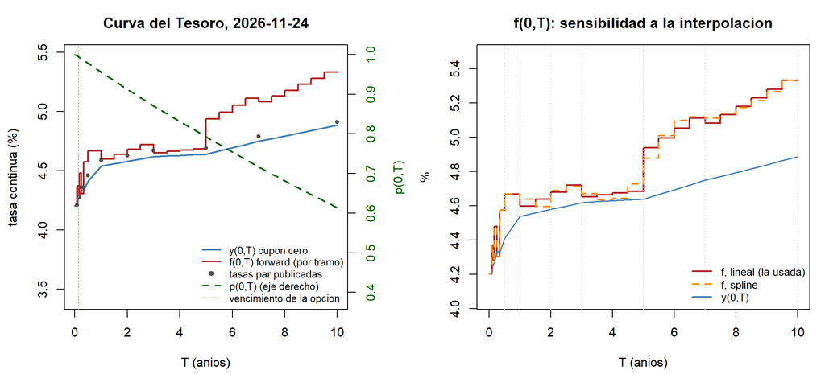

```r
graficar_a <- function() {
  op <- par(mfrow = c(1, 2), mar = c(4.3, 4.3, 3, 4.3)); on.exit(par(op))
  Tk <- cv$T[k10]; fk <- cv$f[k10]
  yl <- range(100 * c(cv$y[k10], fk, cv$par[k10], cv_spl$f[k10])) + c(-0.15, 0.15)
  yl1 <- yl - c(diff(yl) * 0.45, 0)
  plot(Tk, 100 * cv$y[k10], type = "l", lwd = 2.2, col = "steelblue", ylim = yl1, xlim = c(0, TMAX_A),
       xlab = "T (anios)", ylab = "tasa continua (%)", main = sprintf("Curva del Tesoro, %s", fecha_valoracion))
  lines(c(0, Tk), 100 * c(fk, fk[length(fk)]), type = "s", lwd = 2.2, col = "firebrick")
  points(nodos10, 100 * curva_par$tasa[match(nodos10, curva_par$plazo_anios)], pch = 19, cex = .7, col = "grey30")
  abline(v = T, lty = 3, col = "darkorange")
  par(new = TRUE)
  plot(c(0, Tk), c(1, cv$p[k10]), type = "l", lwd = 2.2, lty = 2, col = "darkgreen", axes = FALSE, xlab = "", ylab = "",
       xlim = c(0, TMAX_A), ylim = c(min(cv$p[k10]) - 0.6 * (1 - min(cv$p[k10])), 1))
  axis(4, col.axis = "darkgreen"); mtext("p(0,T)", side = 4, line = 2.8, col = "darkgreen")
  legend("bottomright", c("y(0,T) cupon cero", "f(0,T) forward (por tramo)", "tasas par publicadas",
                          "p(0,T) (eje derecho)", "vencimiento de la opcion"),
         col = c("steelblue", "firebrick", "grey30", "darkgreen", "darkorange"), lwd = c(2, 2, NA, 2, 1),
         lty = c(1, 1, NA, 2, 3), pch = c(NA, NA, 19, NA, NA), bty = "n", cex = .8)
  par(mar = c(4.3, 4.3, 3, 1))
  plot(c(0, Tk), 100 * c(fk, fk[length(fk)]), type = "s", lwd = 2, col = "firebrick", ylim = yl,
       xlab = "T (anios)", ylab = "%", main = "f(0,T): sensibilidad a la interpolacion")
  fs <- cv_spl$f[k10]
  lines(c(0, Tk), 100 * c(fs, fs[length(fs)]), type = "s", lwd = 2, lty = 2, col = "darkorange")
  lines(Tk, 100 * cv$y[k10], col = "steelblue", lwd = 1.5)
  abline(v = nodos10[nodos10 >= 0.5], col = "grey85", lty = 3)
  legend("bottomright", c("f, lineal (la usada)", "f, spline", "y(0,T)"),
         col = c("firebrick", "darkorange", "steelblue"), lwd = 2, lty = c(1, 2, 1), bty = "n", cex = .85)
}
graficar_a()
```

```r
png(file.path(DIR_FIG, "a_curva_hoy.png"), width = 1700, height = 750, res = 150); graficar_a(); invisible(dev.off())
```

## Tarea (b): Vasicek bajo P y bajo Q (caps. 20–21)

**La tasa corta.** Se usa `dtb3_validos`. DTB3 es un rendimiento en base descuento (act/360) de una letra de 91 días. El precio es P = 1 − d·91/360 y la tasa continua es r = −ln(P)/(91/365). Se convierte para que r esté en la misma unidad que y(0,T).

```r
r_dtb3 <- if (CONVERSION_DTB3 == "continua") -log(1 - dtb3_validos$tasa * DIAS_LETRA / 360) / (DIAS_LETRA / 365) else
  dtb3_validos$tasa

fechas_dtb3 <- dtb3_validos$fecha
r0 <- tail(r_dtb3, 1); fecha_r0 <- tail(fechas_dtb3, 1)

cat(sprintf("  DTB3 %s a %s: %d filas, %d sin dato descartadas, quedan %d\n",
            fecha_inicio, fecha_valoracion, nrow(dtb3), nrow(dtb3) - nrow(dtb3_validos), length(r_dtb3)))
```

```
##   DTB3 2021-11-24 a 2026-11-24: 1304 filas, 56 sin dato descartadas, quedan 1248
```

```r
if (fecha_r0 != fecha_valoracion) cat(sprintf("  OJO: DTB3 no tiene dato el %s; r0 es el del %s\n", fecha_valoracion, fecha_r0))
```

```
##   OJO: DTB3 no tiene dato el 2026-11-24; r0 es el del 2026-11-23
```

```r
cat(sprintf("  r0 = DTB3 del %s = %.2f %% (descuento) = %s continua\n", fecha_r0, tail(dtb3_validos$tasa_pct, 1), pct(r0, 3)))
```

```
##   r0 = DTB3 del 2026-11-23 = 4.18 % (descuento) = 4.261 % continua
```

```r
chequeo("r0 (DTB3) vs y(0,3m) de la curva del Tesoro", sprintf("%s vs %s", pct(r0, 3), pct(y0(0.25), 3)),
        "|dif| < 10 pb", abs(r0 - y0(0.25)) < 0.001,
        nota = "Es una alarma, no una prueba: misma letra, dos publicaciones y convenciones. Si falla, revisar fecha y conversion.")
```

```
##   [PASA ] r0 (DTB3) vs y(0,3m) de la curva del Tesoro: 4.261 % vs 4.336 %   (ref.: |dif| < 10 pb)
##           Es una alarma, no una prueba: misma letra, dos publicaciones y convenciones. Si falla, revisar fecha y conversion.
```

**Regresión bajo P y barras de error.** Se estima r_{t+D} = α + β r_t con D = 1/252. Para las barras de error se usa un bootstrap paramétrico: se simulan N_BOOT historias con los parámetros estimados, del mismo largo y con el mismo punto de partida, y se repite la misma regresión en cada una.

```r
est <- est_vasicek(r_dtb3)
if (!est$ok) stop(sprintf("beta = %.6f fuera de (0,1): no hay reversion a la media estimable (a <= 0). ", est$beta),
                  "Eso ya es un diagnostico para la tarea (d).")

aP <- est$a; bP <- est$b; sP <- est$s
cat(sprintf("  %d observaciones ; beta = %.6f ; alpha = %.3e ; sd(e) = %.3e ; R^2 = %.5f\n",
            est$n, est$beta, est$alpha, est$sd_e, summary(est$fit)$r.squared))
```

```
##   1247 observaciones ; beta = 0.996743 ; alpha = 1.631e-04 ; sd(e) = 3.767e-04 ; R^2 = 0.99932
```

```r
cat(sprintf("  a = %.4f (+- %.4f, delta) ; b^P = %.5f ; b^P/a = %s (+- %s) ; sigma = %.5f ; vida media ln2/a = %.2f anios\n",
            aP, 1.96 * est$ee_a, bP, pct(est$mu, 3), pct(1.96 * est$ee_mu, 2), sP, log(2) / aP))
```

```
##   a = 0.8220 (+- 0.3649, delta) ; b^P = 0.04117 ; b^P/a = 5.009 % (+- 0.79 %) ; sigma = 0.00599 ; vida media ln2/a = 0.84 anios
```

```r
set.seed(SEMILLA + 1)
eb <- est_columnas(sim_hist(N_BOOT, length(r_dtb3), r_dtb3[1], aP, bP, sP))
validas <- !is.na(eb[, "a"]) & is.finite(eb[, "b"])
qa <- cuantil(eb[validas, "a"]); qm <- cuantil(eb[validas, "mu"]); qs <- cuantil(eb[validas, "s"])
print(data.frame(parametro = c("a", "b^P/a (%)", "sigma"),
                 p5 = c(qa[1], 100 * qm[1], qs[1]), mediana = c(qa[2], 100 * qm[2], qs[2]),
                 p95 = c(qa[3], 100 * qm[3], qs[3]), estimado = c(aP, 100 * est$mu, sP)), digits = 4, row.names = FALSE)
```

```
##  parametro       p5  mediana      p95 estimado
##          a 0.553386 0.886703 1.344089  0.82200
##  b^P/a (%) 4.297410 4.953169 5.847626  5.00887
##      sigma 0.005813 0.005998 0.006177  0.00599
```

```r
chequeo("la regresion recupera sigma en historias simuladas (sesgo de la mediana)",
        sprintf("%.2f %%", 100 * (qs[2] / sP - 1)), "|sesgo| < 2 %", abs(qs[2] / sP - 1) < 0.02)
```

```
##   [PASA ] la regresion recupera sigma en historias simuladas (sesgo de la mediana): 0.14 %   (ref.: |sesgo| < 2 %)
```

```r
chequeo("sesgo de a en historias simuladas (mediana / verdad)", sprintf("%.2f veces", qa[2] / aP), "informativo", NA,
        nota = "Con 5 anios la regresion sobreestima a (lab del 19/11).")
```

```
##   [INFO ] sesgo de a en historias simuladas (mediana / verdad): 1.08 veces   (ref.: informativo)
##           Con 5 anios la regresion sobreestima a (lab del 19/11).
```

**La curva de la Proposición 21.4 con los parámetros de P, comparada con la de (a), y el ajuste de b solamente.**

```r
TCAL <- nodos10                                    # plazos publicados hasta 10 anios (datos, no interpolados)
ym <- y0(TCAL)
yP <- y_vas(TCAL, r0, aP, bP, sP)
Tg <- seq(0.05, TMAX_A, by = 0.05)
banda  <- apply(sapply(which(validas), function(i) y_vas(Tg,   r0, eb[i, "a"], eb[i, "b"], eb[i, "s"])), 1, cuantil, pr = c(.05, .95))
bandaN <- apply(sapply(which(validas), function(i) y_vas(TCAL, r0, eb[i, "a"], eb[i, "b"], eb[i, "s"])), 1, cuantil, pr = c(.05, .95))
dentro <- ym >= bandaN[1, ] & ym <= bandaN[2, ]

bQ <- calibrar_b(TCAL, ym, r0, aP, sP)              # solo b; a y sigma fijas en las de P
yQ <- y_vas(TCAL, r0, aP, bQ, sP)
bQ_opt <- optimize(function(b_) sum((y_vas(TCAL, r0, aP, b_, sP) - ym)^2), c(-1, 1), tol = 1e-12)$minimum
rmse <- function(e) 1e4 * sqrt(mean(e^2))

comp_b <- data.frame(T = TCAL, mercado = 100 * ym, vasicek_bP = 100 * yP,
                     banda90_inf = 100 * bandaN[1, ], banda90_sup = 100 * bandaN[2, ],
                     dif_P_pb = 1e4 * (yP - ym), vasicek_bQ = 100 * yQ, dif_Q_pb = 1e4 * (yQ - ym))
print(round(comp_b, 3), row.names = FALSE)
```

```
##       T mercado vasicek_bP banda90_inf banda90_sup dif_P_pb vasicek_bQ dif_Q_pb
##   0.083   4.203      4.286       4.262       4.303    8.302      4.281    7.867
##   0.125   4.259      4.298       4.263       4.324    3.911      4.291    3.266
##   0.167   4.265      4.310       4.264       4.345    4.478      4.301    3.627
##   0.250   4.336      4.332       4.266       4.385   -0.396      4.320   -1.643
##   0.333   4.329      4.354       4.267       4.423    2.569      4.338    0.941
##   0.500   4.411      4.395       4.270       4.497   -1.580      4.372   -3.918
##   1.000   4.540      4.498       4.276       4.676   -4.122      4.457   -8.255
##   2.000   4.579      4.641       4.283       4.937    6.184      4.575   -0.429
##   3.000   4.619      4.730       4.287       5.117   11.053      4.648    2.885
##   5.000   4.639      4.828       4.290       5.322   18.876      4.729    8.998
##   7.000   4.749      4.877       4.292       5.473   12.794      4.770    2.057
##  10.000   4.886      4.916       4.293       5.590    2.946      4.802   -8.461
```

```r
cat(sprintf("  b^P = %.5f (regresion) ; b^Q = %.5f (ajuste a la curva)\n", bP, bQ))
```

```
##   b^P = 0.04117 (regresion) ; b^Q = 0.04011 (ajuste a la curva)
```

```r
cat(sprintf("  error RMS contra el mercado: antes del ajuste (b^P) %.1f pb ; despues (b^Q) %.1f pb\n",
            rmse(yP - ym), rmse(yQ - ym)))
```

```
##   error RMS contra el mercado: antes del ajuste (b^P) 8.3 pb ; despues (b^Q) 5.3 pb
```

```r
cat(sprintf("  nivel largo: b^P/a = %s ; b^Q/a = %s ; y(0,inf) bajo Q = %s\n",
            pct(bP / aP, 3), pct(bQ / aP, 3), pct(bQ / aP - sP^2 / (2 * aP^2), 3)))
```

```
##   nivel largo: b^P/a = 5.009 % ; b^Q/a = 4.879 % ; y(0,inf) bajo Q = 4.876 %
```

```r
chequeo("ajuste de b: solucion cerrada = optimize()", sprintf("%.3e", abs(bQ - bQ_opt)), "< 1e-8", abs(bQ - bQ_opt) < 1e-8)
```

```
##   [PASA ] ajuste de b: solucion cerrada = optimize(): 2.776e-17   (ref.: < 1e-8)
```

```r
chequeo("la curva de P (con su banda 90 %) contiene a la de mercado",
        sprintf("%d de %d plazos dentro", sum(dentro), length(TCAL)), "todos dentro = no se distingue P de Q", all(dentro),
        nota = "Si FALLA, la diferencia P vs Q es mayor que el ruido de estimar con 5 anios.")
```

```
##   [FALLA] la curva de P (con su banda 90 %) contiene a la de mercado: 10 de 12 plazos dentro   (ref.: todos dentro = no se distingue P de Q)
##           Si FALLA, la diferencia P vs Q es mayor que el ruido de estimar con 5 anios.
```

```r
chequeo("residuo despues de ajustar solo b (error RMS)", sprintf("%.1f pb", rmse(yQ - ym)), "informativo", NA,
        nota = "Con a y sigma fijas, un solo parametro no fuerza la coincidencia de toda la curva.")
```

```
##   [INFO ] residuo despues de ajustar solo b (error RMS): 5.3 pb   (ref.: informativo)
##           Con a y sigma fijas, un solo parametro no fuerza la coincidencia de toda la curva.
```

**λ implícito, con b^Q = b^P − λσ:**

```r
lam <- (bP - bQ) / sP
lam_b <- sapply(which(validas), function(i)
  (eb[i, "b"] - calibrar_b(TCAL, ym, r0, eb[i, "a"], eb[i, "s"])) / eb[i, "s"])
ql <- cuantil(lam_b)
prima <- function(t) -lam * sP * B_vas(t, aP)       # alpha_T - r = lambda sigma_T, con sigma_T = -sigma B
cat(sprintf("  lambda = (%.5f - %.5f)/%.5f = %.3f ; banda 90 %% (bootstrap) [%.3f, %.3f]\n", bP, bQ, sP, lam, ql[1], ql[3]))
```

```
##   lambda = (0.04117 - 0.04011)/0.00599 = 0.178 ; banda 90 % (bootstrap) [-0.958, 0.943]
```

```r
cat(sprintf("  prima del bono T, -lambda sigma B(0,T): T=1 %s ; T=2 %s ; T=5 %s ; T=10 %s ; T->inf %s\n",
            pb(prima(1), 0), pb(prima(2), 0), pb(prima(5), 0), pb(prima(10), 0), pb(-lam * sP / aP, 0)))
```

```
##   prima del bono T, -lambda sigma B(0,T): T=1 -7 pb ; T=2 -10 pb ; T=5 -13 pb ; T=10 -13 pb ; T->inf -13 pb
```

```r
chequeo("signo de lambda distinguible de cero (banda 90 %)", sprintf("[%.3f, %.3f]", ql[1], ql[3]), "no contiene 0",
        ql[1] > 0 || ql[3] < 0)
```

```
##   [FALLA] signo de lambda distinguible de cero (banda 90 %): [-0.958, 0.943]   (ref.: no contiene 0)
```

**Chequeo Monte Carlo de la Proposición 21.4 con los parámetros bajo Q:**

```r
set.seed(SEMILLA + 2)
dt_mc <- 1 / 252; pasos_mc <- round(5 / dt_mc); ea <- exp(-aP * dt_mc)
sd1 <- sP * sqrt((1 - exp(-2 * aP * dt_mc)) / (2 * aP))
rr <- rep(r0, N_MC); integ <- rep(0, N_MC)
for (paso in 1:pasos_mc) { rn <- rr * ea + (bQ / aP) * (1 - ea) + sd1 * rnorm(N_MC); integ <- integ + dt_mc * (rr + rn) / 2; rr <- rn }
dsc <- exp(-integ); mc5 <- mean(dsc); ee5 <- sd(dsc) / sqrt(N_MC); pf5 <- p_vas(5, r0, aP, bQ, sP)
chequeo("Prop. 21.4 vs Monte Carlo, p(0,5) bajo Q", sprintf("formula %.6f ; MC %.6f +- %.6f", pf5, mc5, 1.96 * ee5),
        "formula dentro del IC 95 %", abs(mc5 - pf5) < 1.96 * ee5)
```

```
##   [PASA ] Prop. 21.4 vs Monte Carlo, p(0,5) bajo Q: formula 0.789413 ; MC 0.789392 +- 0.000143   (ref.: formula dentro del IC 95 %)
```

```r
cat(sprintf("  p(0,T_opcion = %.4f): curva %.6f ; Vasicek b^Q %.6f ; Vasicek b^P %.6f\n",
            T, p0(T), p_vas(T, r0, aP, bQ, sP), p_vas(T, r0, aP, bP, sP)))
```

```
##   p(0,T_opcion = 0.1425): curva 0.993947 ; Vasicek b^Q 0.993899 ; Vasicek b^P 0.993889
```

**Gráfico de la tarea (b):**

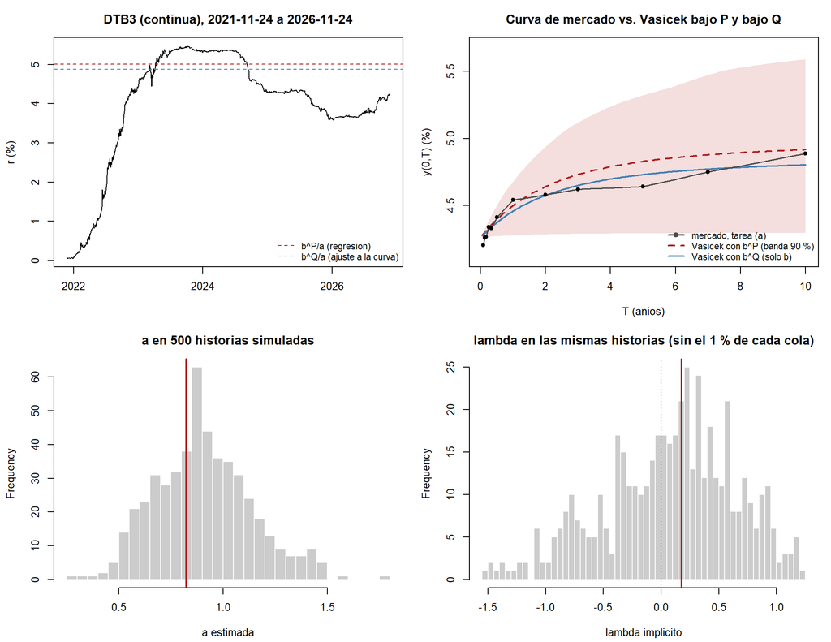

```r
graficar_b <- function() {
  op <- par(mfrow = c(2, 2), mar = c(4.3, 4.3, 3, 1)); on.exit(par(op))
  plot(fechas_dtb3, 100 * r_dtb3, type = "l", xlab = "", ylab = "r (%)", ylim = range(100 * c(r_dtb3, bP / aP, bQ / aP)),
       main = sprintf("DTB3 (%s), %s a %s", CONVERSION_DTB3, fecha_inicio, fecha_valoracion))
  abline(h = 100 * bP / aP, col = "firebrick", lty = 2); abline(h = 100 * bQ / aP, col = "steelblue", lty = 2)
  legend("bottomright", c("b^P/a (regresion)", "b^Q/a (ajuste a la curva)"), col = c("firebrick", "steelblue"),
         lty = 2, bty = "n", cex = .85)
  yl <- range(100 * c(banda, ym, yQ, yP)) + c(-0.1, 0.1)
  plot(Tg, 100 * y_vas(Tg, r0, aP, bP, sP), type = "n", ylim = yl, xlab = "T (anios)", ylab = "y(0,T) (%)",
       main = "Curva de mercado vs. Vasicek bajo P y bajo Q")
  polygon(c(Tg, rev(Tg)), 100 * c(banda[1, ], rev(banda[2, ])), col = adjustcolor("firebrick", .15), border = NA)
  lines(Tg, 100 * y_vas(Tg, r0, aP, bP, sP), col = "firebrick", lwd = 2, lty = 2)
  lines(Tg, 100 * y_vas(Tg, r0, aP, bQ, sP), col = "steelblue", lwd = 2)
  lines(cv$T[k10], 100 * cv$y[k10], col = "grey30", lwd = 1.5); points(TCAL, 100 * ym, pch = 19, cex = .8)
  legend("bottomright", c("mercado, tarea (a)", "Vasicek con b^P (banda 90 %)", "Vasicek con b^Q (solo b)"),
         col = c("grey30", "firebrick", "steelblue"), lwd = 2, lty = c(1, 2, 1), pch = c(19, NA, NA), bty = "n", cex = .85)
  hist(eb[validas, "a"], breaks = 40, col = "grey80", border = "white", xlab = "a estimada",
       main = sprintf("a en %d historias simuladas", sum(validas))); abline(v = aP, col = "firebrick", lwd = 2)
  lb <- lam_b[lam_b > quantile(lam_b, .01) & lam_b < quantile(lam_b, .99)]
  hist(lb, breaks = 40, col = "grey80", border = "white", xlab = "lambda implicito",
       main = "lambda en las mismas historias (sin el 1 % de cada cola)")
  abline(v = lam, col = "firebrick", lwd = 2); abline(v = 0, lty = 3)
}
graficar_b()
```

```r
png(file.path(DIR_FIG, "b_vasicek.png"), width = 1700, height = 1300, res = 150); graficar_b(); invisible(dev.off())
```

## Capa de verificación y salidas de (a) y (b)

```r
cambiados <- .previos_b3[!mapply(identical, .copia_b3,
                                 mget(.previos_b3, envir = globalenv(), ifnotfound = list(NULL)))]
chequeo("objetos de la preparacion de datos intactos despues de (a) y (b)",
        if (length(cambiados)) paste("cambiados:", paste(cambiados, collapse = ", ")) else "ninguno cambio",
        "ninguno cambio", !length(cambiados),
        nota = "Protege lo que usa la tarea (c): T, K, S0, P_T, curva_cero, p0, etc.")
```

```
##   [PASA ] objetos de la preparacion de datos intactos despues de (a) y (b): ninguno cambio   (ref.: ninguno cambio)
##           Protege lo que usa la tarea (c): T, K, S0, P_T, curva_cero, p0, etc.
```

```r
cat("  resultado  podia fallar    chequeo -> valor\n")
```

```
##   resultado  podia fallar    chequeo -> valor
```

```r
for (i in seq_len(nrow(CHEQUEOS)))
  cat(sprintf("  %-9s  %-14s  %s -> %s\n", CHEQUEOS$resultado[i], CHEQUEOS$podia_fallar[i],
              CHEQUEOS$chequeo[i], CHEQUEOS$valor[i]))
```

```
##   PASA       si              p(0,5), curva f = 0.05 - 0.02 e^{-T} -> 0.794427
##   PASA       si              tasa swap anual a 5 anios, caso base (Prop. 19.8) -> 4.6822 %
##   PASA       si              Vasicek p(0,5), a=0.5 b=0.025 sigma=0.01 r0=3 % -> 0.808302
##   PASA       si              curva_variante() reproduce curva_cero y curva_forward -> max dif. = 0.0e+00 ; NA en curva_cero: 0
##   INFO       si              sensibilidad a la interpolacion (lineal vs spline), T <= 10 -> y: 1.38 pb ; f: 6.3 pb ; p(0,T_opcion): 0.0e+00
##   INFO       si              sensibilidad del tramo corto (simple vs semestral del lab) -> y en plazos < 6 m: hasta 3.63 pb ; p(0,T_opcion): 4.5e-05
##   PASA       no (circular)   bonos par de la malla vuelven a valer 1 -> max |P - 1| = 2.2e-16
##   PASA       si              0 < p(0,T) < 1 y decreciente (f > 0) -> min f = 4.203 %
##   INFO       si              Ej. 19.5: y_M <= y <= f en toda la malla T <= 10 -> y_M<=y falla en 0 de 20 plazos ; y<=f falla en 0
##   PASA       no (circular)   tasa swap semestral a 5 anios (Prop. 19.8) = tasa par a 5 anios -> 4.6900 % vs 4.6900 %
##   PASA       si              r0 (DTB3) vs y(0,3m) de la curva del Tesoro -> 4.261 % vs 4.336 %
##   PASA       si              la regresion recupera sigma en historias simuladas (sesgo de la mediana) -> 0.14 %
##   INFO       si              sesgo de a en historias simuladas (mediana / verdad) -> 1.08 veces
##   PASA       si              ajuste de b: solucion cerrada = optimize() -> 2.776e-17
##   FALLA      si              la curva de P (con su banda 90 %) contiene a la de mercado -> 10 de 12 plazos dentro
##   INFO       si              residuo despues de ajustar solo b (error RMS) -> 5.3 pb
##   FALLA      si              signo de lambda distinguible de cero (banda 90 %) -> [-0.958, 0.943]
##   PASA       si              Prop. 21.4 vs Monte Carlo, p(0,5) bajo Q -> formula 0.789413 ; MC 0.789392 +- 0.000143
##   PASA       si              objetos de la preparacion de datos intactos despues de (a) y (b) -> ninguno cambio
```

```r
write.csv(CHEQUEOS, file.path(DIR_SAL, "chequeos_ab.csv"), row.names = FALSE)

resultados_ab <- list(
  fecha_valoracion = fecha_valoracion, forma = forma, swap5 = R5, par5 = par5,
  T_opcion = T, p_opcion = p0(T), r0 = r0, fecha_r0 = fecha_r0, n_obs = est$n,
  P = c(a = aP, b = bP, sigma = sP, mu = est$mu), ee = c(a = est$ee_a, mu = est$ee_mu),
  Q = c(a = aP, b = bQ, sigma = sP), lambda = lam, lambda_banda90 = ql[c(1, 3)],
  rmse_pb = c(P = rmse(yP - ym), Q = rmse(yQ - ym)), tcal = TCAL, y_mercado = ym, y_P = yP, y_Q = yQ,
  boot = eb[validas, ])
saveRDS(resultados_ab, file.path(DIR_SAL, "resultados_ab.rds"))
cat(sprintf("\n  Curva %s: %s ; swap 5a %s = par %s ; p(0,T_opcion) = %.6f\n",
            fecha_valoracion, forma, pct(R5, 3), pct(par5, 3), p0(T)))
```

```
##
##   Curva 2026-11-24: creciente, salvo bajas menores a 5 pb (0.25-0.333 a: -0.8 pb) ; swap 5a 4.690 % = par 4.690 % ; p(0,T_opcion) = 0.993947
```

```r
cat(sprintf("  Vasicek P: a = %.3f, b^P/a = %s, sigma = %.4f ; Q (solo b): b^Q/a = %s ; lambda = %.3f [%.3f, %.3f]\n",
            aP, pct(bP / aP), sP, pct(bQ / aP), lam, ql[1], ql[3]))
```

```
##   Vasicek P: a = 0.822, b^P/a = 5.01 %, sigma = 0.0060 ; Q (solo b): b^Q/a = 4.88 % ; lambda = 0.178 [-0.958, 0.943]
```

```r
cat(sprintf("  %d chequeos: %d PASA, %d FALLA, %d informativos\n", nrow(CHEQUEOS), sum(CHEQUEOS$resultado == "PASA"),
            sum(CHEQUEOS$resultado == "FALLA"), sum(CHEQUEOS$resultado == "INFO")))
```

```
##   19 chequeos: 12 PASA, 2 FALLA, 5 informativos
```

## Tarea (c). Valoración de la call con tasa estocástica

### 1. Fórmula de la call y varianza integrada

La volatilidad de la acción es $\sigma_S$ y la volatilidad de la tasa corta es $\sigma_r$. Para un bono que vence junto con la opción, la volatilidad del bono es $-\sigma_r B(t,T)$. La varianza integrada que entra en la fórmula de la call es

$$\Sigma^2(\rho)=\int_0^T
\left[\sigma_S^2+\sigma_r^2 B(t,T)^2
+2\rho\,\sigma_S\sigma_r B(t,T)\right]dt,
\qquad
B(t,T)=\frac{1-e^{-a(T-t)}}{a}.$$

```r
# La función recibe Sigma² para toda la vida de la opción.
# El descuento P y el rendimiento por dividendos q entran por separado.
call_varianza <- function(S, K, T, P, q, varianza) {
  spot_ajustado <- S * exp(-q * T)
  strike_descontado <- K * P

  if (varianza == 0) {
    return(max(spot_ajustado - strike_descontado, 0))
  }

  Sigma <- sqrt(varianza)
  d1 <- log(spot_ajustado / strike_descontado) / Sigma + Sigma / 2
  d2 <- d1 - Sigma

  spot_ajustado * pnorm(d1) - strike_descontado * pnorm(d2)
}

varianza_vasicek <- function(T, a, sigma_r, sigma_S, rho) {
  stopifnot(T > 0, a > 0, sigma_r >= 0, sigma_S >= 0, abs(rho) <= 1)

  integrando <- function(t) {
    B <- B_vas(T - t, a)  # B_vas() ya se definió en la tarea (b)
    # Equivale al integrando de la guía y conserva la no negatividad.
    (sigma_S + rho * sigma_r * B)^2 +
      (1 - rho^2) * (sigma_r * B)^2
  }

  integrate(integrando, lower = 0, upper = T, rel.tol = 1e-10)$value
}
```

### 2. Verificación con los casos del curso

Antes de usar los datos de NTR, se reproducen los tres precios con Vasicek y el precio de Black–Scholes indicados en la guía.

```r
rho_c <- c(-1, 0, 1)

var_guia <- vapply(
  rho_c,
  function(rho) varianza_vasicek(
    T = 1, a = 0.5, sigma_r = 0.01, sigma_S = 0.20, rho = rho
  ),
  numeric(1)
)

# En Black–Scholes la varianza integrada es sigma_S² * T.
var_guia <- c(var_guia, 0.20^2 * 1)

precios_guia <- vapply(
  var_guia,
  function(v) call_varianza(
    S = 100, K = 100, T = 1, P = 0.963332, q = 0, varianza = v
  ),
  numeric(1)
)

controles_c <- data.frame(
  caso = c("Vasicek, rho = -1", "Vasicek, rho = 0",
           "Vasicek, rho = 1", "Black–Scholes"),
  referencia = c(9.6259, 9.7907, 9.9521, 9.7885),
  calculado = unname(precios_guia)
)

for (i in seq_len(nrow(controles_c))) {
  chequeo(
    nombre = paste("Call del curso", controles_c$caso[i]),
    valor = sprintf("%.6f", controles_c$calculado[i]),
    referencia = sprintf("%.4f", controles_c$referencia[i]),
    pasa = abs(controles_c$calculado[i] - controles_c$referencia[i]) < 0.00005
  )
}
```

```
##   [PASA ] Call del curso Vasicek, rho = -1: 9.625864   (ref.: 9.6259)
##   [PASA ] Call del curso Vasicek, rho = 0: 9.790696   (ref.: 9.7907)
##   [PASA ] Call del curso Vasicek, rho = 1: 9.952140   (ref.: 9.9521)
##   [PASA ] Call del curso Black–Scholes: 9.788467   (ref.: 9.7885)
```

```r
controles_c
```

```
##                caso referencia calculado
## 1 Vasicek, rho = -1     9.6259  9.625864
## 2  Vasicek, rho = 0     9.7907  9.790696
## 3  Vasicek, rho = 1     9.9521  9.952140
## 4     Black–Scholes     9.7885  9.788467
```

### 3. Insumos de la call de NTR

Se utiliza el descuento de mercado de la tarea (a) y los parámetros $a$ y $\sigma_r$ estimados en (b). La volatilidad de la acción $\sigma_S$ se aproxima con la volatilidad implícita de la call seleccionada. Todos los escenarios usan los mismos insumos.

```r
P_c <- p0(T)
r_c <- y0(T)
sigma_r_c <- sP
sigma_S_c <- sigma_call

# Aproximación de dividendo continuo basada en el último pago trimestral
# documentado en la Bitácora 2. No supone una fecha ex-dividendo observada.
dividendo_trimestral_c <- 0.55
q_c <- 4 * dividendo_trimestral_c / S0

bid_c <- call_enero$bid
ask_c <- call_enero$ask
mid_c <- (bid_c + ask_c) / 2

stopifnot(
  nrow(call_enero) == 1L, T > 0, P_c > 0, sigma_S_c > 0,
  bid_c <= ask_c, abs(P_c - exp(-r_c * T)) < 1e-10
)

insumos_c <- data.frame(
  fecha = fecha_valoracion, vence = vencimiento, dias = dias,
  spot = S0, strike = K, descuento = P_c, tasa_cero_pct = 100 * r_c,
  a = aP, sigma_r = sigma_r_c, IV_call_pct = 100 * sigma_S_c,
  q_pct = 100 * q_c, bid = bid_c, ask = ask_c, mid = mid_c
)

insumos_c
```

```
##        fecha      vence dias  spot strike descuento tasa_cero_pct         a     sigma_r IV_call_pct   q_pct bid ask mid
## 1 2026-11-24 2027-01-15   52 66.33   67.5  0.993947      4.261667 0.8220022 0.005989656     32.9173 3.31675 2.4   3 2.7
```

### 4. Vasicek frente a Black–Scholes para el mismo contrato

Se valora la call con $\rho=-1,0,1$. La referencia Black–Scholes usa $r=y(0,T)$, de modo que ambos modelos tienen el mismo descuento. La diferencia de precio mide el efecto de cambiar la varianza integrada.

```r
var_ntr <- vapply(
  rho_c,
  function(rho) varianza_vasicek(T, aP, sigma_r_c, sigma_S_c, rho),
  numeric(1)
)

precio_ntr <- function(v, q = q_c) {
  call_varianza(S0, K, T, P_c, q, v)
}

call_vas_c <- vapply(var_ntr, precio_ntr, numeric(1))
call_bs_c <- precio_ntr(sigma_S_c^2 * T)

resultados_c <- data.frame(
  modelo = c("Black–Scholes", rep("Vasicek", 3)),
  rho = c(NA_real_, rho_c),
  Sigma = sqrt(c(sigma_S_c^2 * T, var_ntr)),
  precio_USD = c(call_bs_c, call_vas_c)
)

resultados_c$dif_vs_BS_USD <- resultados_c$precio_USD - call_bs_c
resultados_c$dif_vs_mid_USD <- resultados_c$precio_USD - mid_c

knitr::kable(resultados_c, digits = 5,
             caption = "Precios en USD por acción. Diferencias con signo.")
```

Precios en USD por acción. Diferencias con signo.

| modelo | rho | Sigma | precio_USD | dif_vs_BS_USD | dif_vs_mid_USD |
| --- | --- | --- | --- | --- | --- |
| Black–Scholes | NA | 0.12425 | 2.78744 | 0.00000 | 0.08744 |
| Vasicek | -1 | 0.12409 | 2.78337 | -0.00407 | 0.08337 |
| Vasicek | 0 | 0.12425 | 2.78744 | 0.00000 | 0.08744 |
| Vasicek | 1 | 0.12440 | 2.79151 | 0.00407 | 0.09151 |

```r
# ¿Cuánto importa la tasa estocástica para esta opción de pocos meses?
impacto_max_c <- max(abs(call_vas_c - call_bs_c))
spread_c <- ask_c - bid_c

cat(sprintf(
  "Para los %d días restantes, la mayor diferencia absoluta frente a Black–Scholes es USD %.5f por acción (%.3f %% del precio BS).",
  dias, impacto_max_c, 100 * impacto_max_c / call_bs_c
))
```

```
## Para los 52 días restantes, la mayor diferencia absoluta frente a Black–Scholes es USD 0.00407 por acción (0.146 % del precio BS).
```

```r
if (spread_c > 0) {
  cat(sprintf(
    "\nEl spread bid–ask es USD %.2f. La diferencia máxima equivale al %.2f %% de ese spread.",
    spread_c, 100 * impacto_max_c / spread_c
  ))
}
```

```
##
## El spread bid–ask es USD 0.60. La diferencia máxima equivale al 0.68 % de ese spread.
```

```r
# Sensibilidad al supuesto de dividendos, manteniendo rho = 0.
i_central <- match(0, rho_c)
call_sin_div_c <- precio_ntr(var_ntr[i_central], q = 0)

cat(sprintf(
  "\nCon rho = 0, el precio es USD %.4f con q = %.3f %% y USD %.4f con q = 0.",
  call_vas_c[i_central], 100 * q_c, call_sin_div_c
))
```

```
##
## Con rho = 0, el precio es USD 2.7874 con q = 3.317 % y USD 2.9377 con q = 0.
```

### 5. Cuadro de las tres bitácoras

Se comparan las calls cercanas al dinero seleccionadas en cada fecha. Para la Bitácora 3 se presenta $\rho=0$ como escenario central y se reportan los otros dos escenarios en el cuadro anterior.

```r
cuadro_tres_bitacoras <- data.frame(
  concepto = c("Fecha de cotización", "Vencimiento", "Strike (USD)",
               "Método", "Precio teórico (USD)", "Mercado mid (USD)"),
  `Bitácora 1` = c(
    "28/09/2026", "18/12/2026", "72.50",
    "Black–Scholes con dividendo equivalente", "4.3290", "4.55"
  ),
  `Bitácora 2` = c(
    "02/11/2026", "18/12/2026", "70.00",
    "Monte Carlo repesado, deriva estimada", "3.0587", "3.60"
  ),
  `Bitácora 3` = c(
    format(fecha_valoracion, "%d/%m/%Y"),
    format(vencimiento, "%d/%m/%Y"),
    sprintf("%.2f", K),
    "Vasicek, rho = 0, con dividendo equivalente",
    sprintf("%.4f", call_vas_c[i_central]),
    sprintf("%.2f", mid_c)
  ),
  check.names = FALSE
)

knitr::kable(cuadro_tres_bitacoras, align = c("l", "c", "c", "c"),
             caption = "Call de Nutrien. Precios en USD por acción.")
```

Call de Nutrien. Precios en USD por acción.

| concepto | Bitácora 1 | Bitácora 2 | Bitácora 3 |
| --- | --- | --- | --- |
| Fecha de cotización | 28/09/2026 | 02/11/2026 | 24/11/2026 |
| Vencimiento | 18/12/2026 | 18/12/2026 | 15/01/2027 |
| Strike (USD) | 72.50 | 70.00 | 67.50 |
| Método | Black–Scholes con dividendo equivalente | Monte Carlo repesado, deriva estimada | Vasicek, rho = 0, con dividendo equivalente |
| Precio teórico (USD) | 4.3290 | 3.0587 | 2.7874 |
| Mercado mid (USD) | 4.55 | 3.60 | 2.70 |

```r
cuadro_tres_bitacoras
```

```
##               concepto                              Bitácora 1                            Bitácora 2
## 1  Fecha de cotización                              28/09/2026                            02/11/2026
## 2          Vencimiento                              18/12/2026                            18/12/2026
## 3         Strike (USD)                                   72.50                                 70.00
## 4               Método Black–Scholes con dividendo equivalente Monte Carlo repesado, deriva estimada
## 5 Precio teórico (USD)                                  4.3290                                3.0587
## 6    Mercado mid (USD)                                    4.55                                  3.60
##                                    Bitácora 3
## 1                                  24/11/2026
## 2                                  15/01/2027
## 3                                       67.50
## 4 Vasicek, rho = 0, con dividendo equivalente
## 5                                      2.7874
## 6                                        2.70
```

```r
# ¿Qué bQ necesitaría Vasicek para calzar cada plazo por separado?
plazos_d <- c(2, 5, 10)

bQ_por_plazo <- vapply(plazos_d, function(t) {
  calibrar_b(t, y0(t), r0, aP, sP)
}, numeric(1))

diagnostico_d <- data.frame(
  plazo_anios = plazos_d,
  bQ_exacto = bQ_por_plazo,
  lambda_implicito = (bP - bQ_por_plazo) / sP,
  error_con_bQ_unico_pb = 1e4 * (
    y_vas(plazos_d, r0, aP, bQ, sP) - y0(plazos_d)
  )
)

print(round(diagnostico_d, 4), row.names = FALSE)
```

```
##  plazo_anios bQ_exacto lambda_implicito error_con_bQ_unico_pb
##            2    0.0402           0.1667               -0.4293
##            5    0.0391           0.3406                8.9977
##           10    0.0409           0.0460               -8.4613
```

```r
# Costo del ajuste con un solo parámetro en todos los nodos de (b).
cat(sprintf("\nRMSE de la curva con un único bQ: %.2f pb\n",
            sqrt(mean(comp_b$dif_Q_pb^2))))
```

```
##
## RMSE de la curva con un único bQ: 5.31 pb
```

```r
# Efecto sobre la call: cambiar únicamente el descuento, con rho = 0.
i0 <- match(0, rho_c)
precio_curva_d <- call_varianza(S0, K, T, p0(T), q_c, var_ntr[i0])
precio_vas_d <- call_varianza(
  S0, K, T, p_vas(T, r0, aP, bQ, sP), q_c, var_ntr[i0]
)

cat(sprintf(
  "Call con descuento del Tesoro: USD %.5f\nCall con descuento de Vasicek: USD %.5f\nDiferencia por acción: USD %+.5f\n",
  precio_curva_d, precio_vas_d, precio_vas_d - precio_curva_d
))
```

```
## Call con descuento del Tesoro: USD 2.78744
## Call con descuento de Vasicek: USD 2.78881
## Diferencia por acción: USD +0.00137
```